# Analyse des Communautées d’amphibiens - Maîtrise en biologie

Author

Claudie Bouffard

## Glossaire :

### Liste d’espèces sélectionnées :

- **Ambystoma :** Salamandres du genre *Ambystoma*. Les espèces présentes au Québec, la salamandre maculée (*A. maculatum*), la salamandre à points bleues (*A. laterale*) et/ou salamandres du complexe de Jerfferson (*A. jeffersonianum complex*), sont incluses dans cette étude. Celles-ci sont toutes des espèces concidérées comme dépendantes des étangs vernaux et qui partagent un cycle de vie similaires.
- **LISY :** Grenouille des bois (Lithobates sylvaticus). Espèce dépendante des étangs vernaux.
- **LICL :** Grenouille verte (*Lithobates clamitans*). Espèce associée aux habitats à canopées ouvertes et étangs permanents. Représente de la compétition/prédateur pour les espèces dépendantes des étangs vernaux.
- **PSCR :** Rainette cucifère (Pseudacris crucifer). Espèce versatile et non-prédatrice des espèces dépendantes des étangs vernaux.

### Liste de type de traitements:

- **PEH :** Plantation de peuplier hybrides sur monticule (entre 1 à 5 ans). Les arbres sont trop jeunes pour avoir un effet sur l’hydrologie par evapotranspiration. Canopée particulièrement ouverte car les arbres sont petits.
- **CPPTM :** Coupe avec Protection des Petites Tiges Marchandes. Similaire à la coupe totale mais certains jeunes arbres sont laissés sur place. Ceux-ci ont tendance à tomber avec le vent. Sur les terres de DOMTAR, cette pratique est majoritairement dans des peuplements résineux mais a été vu dans du feuillus
- **CJ :** Coupe de Jardinage. Coupe qui imite le régime de trouée naturel des forêts de feuillus matures. Cela n’empêche la dégradation du sol par les ornières de machinerie. La canopée reste fermée.
- **NAT:** Étangs vernaux sélectionnées dans des milieux protégés depuis au moins 70 ans. Celui-ci représente le contrôle pour mon étude.

## Est-ce que la communauté d’amphibiens diffère entre les types de traitements sylvicoles ?

1. **Création de la base de donnée**

   ```r
   library(readxl)
   df2 <-read_excel("C:/Users/super/Université du Québec en Outaouais/CLAUDIE ÉTANGS VERNAUX - Documents/Stats/Structure_des_communautes/Data_Base_presenceV7.xlsx", sheet = 1)
   df2 <- df2[, 1:6]
   df2$No_etang <- as.factor(df2$No_etang)
   df2$Traitement <- as.factor(df2$Traitement)
   mat2 <- df2[, !(names(df2) %in% c("No_etang", "Traitement"))]
   mat2
   ```

   ```
   # A tibble: 57 × 4
      ambystoma  LICL  LISY  PSCR
          <dbl> <dbl> <dbl> <dbl>
    1         0     0     1     0
    2         1     0     1     0
    3         1     0     0     0
    4         1     0     0     0
    5         1     0     1     0
    6         1     0     1     1
    7         0     0     1     0
    8         0     0     1     1
    9         0     0     1     1
   10         0     0     1     1
   # ℹ 47 more rows
   ```

2. **Calcul de l’indice de Jaccard**

   ```r
   library(vegan)
   jac2 <- vegdist(mat2, method = "jaccard", binary = TRUE)
   ```

3. **Test des conditions: Homogénité des dispersions**

   ```r
   bd <- betadisper(jac2, df2$Traitement)
   anova(bd)
   ```

   ```
   Analysis of Variance Table

   Response: Distances
             Df  Sum Sq  Mean Sq F value Pr(>F)
   Groups     3 0.22018 0.073395  1.3963 0.2541
   Residuals 53 2.78592 0.052565
   ```

   ```r
   permutest(bd)
   ```

   ```
   Permutation test for homogeneity of multivariate dispersions
   Permutation: free
   Number of permutations: 999

   Response: Distances
             Df  Sum Sq  Mean Sq      F N.Perm Pr(>F)
   Groups     3 0.22018 0.073395 1.3963    999  0.261
   Residuals 53 2.78592 0.052565
   ```

   Ici, le résultats de l’ANOVA et du permutest du betadisper est non significatif. Donc, la condition est respecté. Pas besoin de modifier la base de donnée.
4. **PERMANOVA:**

   ```r
   PERMANOVA1 <- adonis2(jac2 ~ df2$Traitement,permutations = 9999)
   PERMANOVA1
   ```

   ```
   Permutation test for adonis under reduced model
   Permutation: free
   Number of permutations: 9999

   adonis2(formula = jac2 ~ df2$Traitement, permutations = 9999)
            Df SumOfSqs      R2      F Pr(>F)
   Model     3   2.7201 0.27193 6.5983  1e-04 ***
   Residual 53   7.2829 0.72807
   Total    56  10.0030 1.00000
   ---
   Signif. codes:  0 '***' 0.001 '**' 0.01 '*' 0.05 '.' 0.1 ' ' 1
   ```

   C’est significatif ! La communauté d’amphibiens dans au moins un type de traitement sylvicole diffère des autres.
5. **Test Post-Hoc: Pairwise à la main.**

   Malheureusement, le package qui s’occupait de faire le pairwise pour la PERMANOVA (pairwiseAdonis) n’est présentement plus fonctionnel avec les récentes versions de R. Ainsi, il faut maintenant créer la fonction à la main.

   ```r
   pairwise_permanova <- function(data, group, method = "jaccard", nperm = 999) {
     groups <- levels(group)
     comb <- combn(groups, 2, simplify = FALSE)

     results <- data.frame()

     set.seed(123) #permet d'obtenir constament le même résultat

      for (i in comb) {
       sel <- group %in% i
       sub_data <- data[sel, ]
       sub_group <- droplevels(group[sel])

       ad <- adonis2(sub_data ~ sub_group,
                     method = method,
                     binary = TRUE,
                     permutations = nperm)

       results <- rbind(results,
                        data.frame(group1 = i[1],
                                   group2 = i[2],
                                   F = ad$F[1],
                                   R2 = ad$R2[1],
                                   p = ad$`Pr(>F)`[1])) }

     #Correction avec la procédure de Benjamin et Hochberg (FDR)
     results$p_adj <- p.adjust(results$p, method = "BH")
     results}
   ```

   Avec cette fonction, il est maintenant possible de faire le pairwise.

   ```r
   pairwise_permanova(mat2, df2$Traitement)
   ```

   ```
     group1 group2         F         R2     p p_adj
   1     CJ  CPPTM  4.893929 0.13264862 0.016 0.024
   2     CJ    NAT  1.167213 0.04829739 0.275 0.275
   3     CJ    PEH  9.512882 0.21862219 0.001 0.003
   4  CPPTM    NAT  8.860500 0.31803091 0.004 0.008
   5  CPPTM    PEH  3.139662 0.09474030 0.040 0.048
   6    NAT    PEH 15.677254 0.42743805 0.001 0.003
   ```

   Tout est significatif à part CJ et NAT ! Ainsi, toutes les communautés de chaque traitements diffèrent les unes des autres sauf les communautés de CJ et de NAT qui sont théoriquement similaires.
6. **Visualisation : NDMS**

   Un NDMS est une bonne méthode pour visualiser les résultats d’une PERMANOVA.

   ```r
   set.seed(123)  # s'assure d'avoir des résultats constants
   nmds2 <- metaMDS(mat2,distance = "jaccard",binary=TRUE,k=2,trymax=100,autotransform=FALSE, trace = 0)
   nmds2$stress
   ```

   ```
   [1] 0.05394578
   ```

   stress = 0.05 ce qui est bas. Ceci assure que la positions des points dans le graphique est représentatif.

   Puisque la PERMANOVA analyse la position moyenne des communautés, de pouvoir visualiser les centroïdes permettent d’essentiellement de voir ce que la PERMANOVA analyse entre chaque traitement. Ainsi, voici comment j’ai extrait les centroïdes:

   ```r
   scores <- scores(nmds2, display = "sites")
   cent <- aggregate(scores, by = list(trait = df2$Traitement), FUN = mean)
   colnames(scores)
   ```

   ```
   [1] "NMDS1" "NMDS2"
   ```

   De plus, plusieurs points partagent la même communauté d’amphibiens. Ainsi,du jitter doit être appliqué pour mieux visualiser les résultats

   ```r
   set.seed(123) # s'assure d'avoir des résultats constants
   sc_jit <- scores
   sc_jit[,1] <- jitter(scores[,1], amount = 0.02)
   sc_jit[,2] <- jitter(scores[,2], amount = 0.02)
   ```

   Avec cela, on est prêt à faire le graphique du NDMS

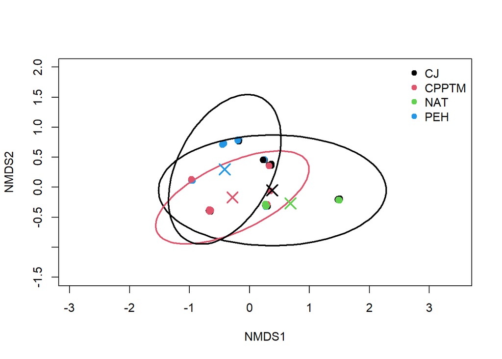

   ```r
   plot(nmds2, type = "n", ylim=c(-1.5,2))
   points(sc_jit,
          col = df2$Traitement,
          pch = 19,
          cex = 1.2)
   ordiellipse(nmds2,
     groups = df2$Traitement,
     show.groups = c("CJ", "CPPTM", "PEH"),
     kind = "sd",
     conf = 0.95,  draw = "line", col = c(1,2,4),
     lwd = 2)
   legend("topright",
     legend = levels(df2$Traitement),
     col = 1:length(levels(df2$Traitement)),
     pch = 19,
     bty = "n")
   points(cent$NMDS1, cent$NMDS2,
          pch = 4, cex = 2, lwd = 2,
          col = 1:length(levels(df2$Traitement)))
   ```

   | n NAT = 6 n CJ = 19 | n CPPTM = 15 n PEH = 17 |
   | --- | --- |

   Ici, je n’ai pas fait apparaître l’ellipse de NAT puisqu’elle était représentée que par une ligne. Ceci est dut par la faible diversité des communautés d’amphibiens. Ainsi, NAT n’est représenté que par des points.
7. **Conclusion :**

   Les communautés d’amphibiens varies tous selon les types de traitements sauf les communautés qui se trouvent dans les étangs de CJ et NAT. Ainsi les communautés d’amphibiens dans les CJ sont similaire au milieux naturel utilisé en référence. Il semblerait alors que les communautés dans les plantations de PEH dans DOMTAR ne reflèterait pas le milieu naturel.

## Comment est-ce que les valeurs environnementales expliquent la composition en espèces d’amphibiens ?

Liste des valeurs environnementales incluses:

- **Température :** Moyenne en Celcius
- **pH :** Moyenne
- **Surface :** Surface maximale calculée pour l’étang en cm2
- **Volume :** Volume maximale calculé pour l’étang en Litres
- **Pourcentage d’ouverture de la canopée :** Moyenne des points Nord, Sud, Est, West. 100% = complètement ouvert sans végétation, 0% = complètement fermée par la végétation.
- **Quantité de débris ligneux dans l’étang :** Quantité de débris ligneux qui se trouve dans l’étang. Les débris ligneux est une caractéristique important pour attacher les oeufs des amphibiens. Classé en 4 niveau de présence: Abscent, Faible, Moyen et Élevée
- **Quantité de débris ligneux autour l’étang :** Quantité de débris ligneux qui se trouve dans un périmètre de 10m autour de l’étang. Les débris ligneux hors de l’étang sert de refuge humide pour les amphibiens en phase terrestres (juvéniles et adultes reproducteurs). Classé en 4 niveau de présence: Abscent, Faible, Moyen et Élevée.
- **Hydropériode :** Pour éviter des biais liée aux dates de fin de prise de données qui varie selon le type de traitement (dut aux limitations de terrain), l’hydropériode a été classé en deux niveau. Sec ou humide pour refléter l’état de l’étang à la fin de la prise de données. Les étangs concidérés ‘’humides’’ n’ont jamais séchés durant la prise de donnée.

Avec cela, voici l’analyse que j’ai fait :

1. **Préparation de la base de donnée :**

   ```r
   library(readxl)
   df2 <-read_excel("C:/Users/super/Université du Québec en Outaouais/CLAUDIE ÉTANGS VERNAUX - Documents/Stats/Structure_des_communautes/Data_Base_presenceV7.xlsx", sheet = 1)
   df2$Traitement <- as.factor(df2$Traitement)
   df2$Ph_moy <- as.numeric(df2$Ph_moy)
   df2$Temp_moy <- as.numeric(df2$Temp_moy)
   df2$superficie <- as.numeric(df2$superficie)
   df2$volume <- as.numeric(df2$volume)
   df2$Ouverture <- as.numeric(df2$Ouverture)
   df2[, 2:5] <- lapply(df2[, 2:5], as.numeric)
   df2$Debris_in<- as.numeric(factor(df2$Debris_in,levels = c("abscence", "faible", "moyen", "eleve"),ordered = TRUE))
   df2$Debris_out<- as.numeric(factor(df2$Debris_out,levels = c("abscence", "faible", "moyen", "eleve"),ordered = TRUE))
   #pour débris, voici les codes: 1=abscence, 2=faible, 3=moyen, 4=eleve)
   df2$Hydro<- factor(df2$Hydro, levels = c("hum", "sec"))
   df2
   ```

   ```
   # A tibble: 57 × 14
      No_etang   ambystoma  LICL  LISY  PSCR Traitement Ph_moy Temp_moy superficie
      <chr>          <dbl> <dbl> <dbl> <dbl> <fct>       <dbl>    <dbl>      <dbl>
    1 1WATCJ6            0     0     1     0 CJ           6.64     15.0    165000
    2 2WATCJ5            1     0     1     0 CJ           6.58     16.6    434700
    3 3WATCJ1            1     0     0     0 CJ           6.44     12.0     26600
    4 4WATCJ2            1     0     0     0 CJ           6.62     17.7    380800
    5 5WATCJ4            1     0     1     0 CJ           6.38     18.6     72000
    6 6WATCJ3            1     0     1     1 CJ           6.26     18.5    240000
    7 17WATPEH10         0     0     1     0 PEH          6.49     22.2     62059.
    8 7WATPEH2           0     0     1     1 PEH          6.33     15.6    267285.
    9 12WATPEH5          0     0     1     1 PEH          6.32     17.5    574453.
   10 8WATPEH1           0     0     1     1 PEH          6.49     13.9    133706.
   # ℹ 47 more rows
   # ℹ 5 more variables: volume <dbl>, Ouverture <dbl>, Debris_in <dbl>,
   #   Debris_out <dbl>, Hydro <fct>
   ```

   ```r
   #Puisque cette base de donnée est grosse, je vais créer des objets pour faciliter les prochaines étapes.

   sp2=df2[, 2:5]
   trait2=df2$Traitement

   env <- df2[, c("Ph_moy", "Temp_moy", "superficie", "volume","Ouverture", "Debris_in", "Debris_out","Hydro")]
   env
   ```

   ```
   # A tibble: 57 × 8
      Ph_moy Temp_moy superficie volume Ouverture Debris_in Debris_out Hydro
       <dbl>    <dbl>      <dbl>  <dbl>     <dbl>     <dbl>      <dbl> <fct>
    1   6.64     15.0    165000   3878.     17.2          2          2 hum
    2   6.58     16.6    434700   5216.      5.2          1          2 hum
    3   6.44     12.0     26600    466.     26            1          2 sec
    4   6.62     17.7    380800  11805.      1.04         2          2 sec
    5   6.38     18.6     72000   1548       4.68         1          2 hum
    6   6.26     18.5    240000   5040       8.58         1          2 sec
    7   6.49     22.2     62059.   993.     51.0          1          1 hum
    8   6.33     15.6    267285.  8019.     72.8          1          1 hum
    9   6.32     17.5    574453. 11489.     78.3          1          2 hum
   10   6.49     13.9    133706.  4011.     44.7          1          1 hum
   # ℹ 47 more rows
   ```

   ```r
   Temperature <- env$Temp_moy
   pH <- env$Ph_moy
   Superficie <- env$superficie
   Volume <- env$volume
   Pourcentage_Ouverture <- env$Ouverture
   Presence_debris_hors_etang <- env$Debris_out
   Presence_debris_dans_etang <- env$Debris_in
   Hydro_ <- env$Hydro
   ```

2. **CCA ou RDA ? :**

   Pour savoir quel type d’analyse est la meilleure pour mes données, faut faire un test DCA

   ```r
   decorana(sp2)
   ```

   ```
   Call:
   decorana(veg = sp2)

   Detrended correspondence analysis with 26 segments.
   Rescaling of axes with 4 iterations.
   Total inertia (scaled Chi-square): 0.9308

                          DCA1   DCA2   DCA3    DCA4
   Eigenvalues          0.4044 0.2874 0.2930 0.28819
   Additive Eigenvalues 0.4044 0.2752 0.2512 0.00000
   Decorana values      0.4109 0.1354 0.0241 0.01099
   Axis lengths         2.2990 1.5051 1.6310 1.81649
   ```

   ```r
   sp3=decostand(sp2, method = "hellinger")
   ```

3. **Choix du modèle :**

   Premièrement, faut voir s’il y a de la collinéarité

   ```r
   modrda1 <- rda(sp3 ~ pH + Temperature + Superficie + Volume + Pourcentage_Ouverture + Presence_debris_dans_etang + Presence_debris_hors_etang+Hydro_)
   vif.cca(modrda1)
   ```

   ```
                           pH                Temperature
                     1.175336                   1.927607
                   Superficie                     Volume
                     2.522387                   2.469785
        Pourcentage_Ouverture Presence_debris_dans_etang
                     1.769459                   2.020207
   Presence_debris_hors_etang                  Hydro_sec
                     2.290920                   1.417333
   ```

   Tout est sous 3 donc tout va bien, pas de collinéarité.

   J’ai essayé plusieurs méthodes pour trouver un bon modèle, mais le meilleur (R2 élevé en plus d’être parcimonieux) est ressorti avec ordistep()

   ```r
   modrda_null <- rda(sp3 ~ 1, data = env)
   select1 <- ordistep(modrda_null,scope = formula(modrda1),direction = "both",permutations = 999, trace = 0)
   select1
   ```

   ```
   Call: rda(formula = sp3 ~ Pourcentage_Ouverture + Hydro_ +
   Presence_debris_dans_etang, data = env)

                 Inertia Proportion Rank
   Total          0.3802     1.0000
   Constrained    0.1246     0.3277    3
   Unconstrained  0.2556     0.6723    4

   Inertia is variance

   Eigenvalues for constrained axes:
      RDA1    RDA2    RDA3
   0.09913 0.02210 0.00334

   Eigenvalues for unconstrained axes:
       PC1     PC2     PC3     PC4
   0.12826 0.06598 0.04792 0.01347
   ```

   modrda6 <- rda(sp3 ~ Pourcentage_Ouverture +Hydro_+ Presence_debris_dans_etang)
   RsquareAdj(modrda6)
   ```

   ```
   $r.squared
   [1] 0.3276545

   $adj.r.squared
   [1] 0.2895972
   ```

   Le modèle explique environ 28,96% de la variation de la communauté d’amphibiens ce qui est excellent.
4. **Visualisation :**

   Tout comme la PERMANOVA, il est préférable de voir les centroïdes. Ainsi, voici comment je les aient extraient

   ```r
   scores3 <- scores(modrda6, display = "sites")
   cent3 <- aggregate(scores3, by = list(trait = trait2), FUN = mean)
   ```

   Plusieurs points se superposent. Du jitter est donc préférable pour mieux interpréter le graphique

   ```r
   set.seed(123)
   scores3_jit <- scores3
   scores3_jit[,1] <- jitter(scores3[,1], amount = 0.03)
   scores3_jit[,2] <- jitter(scores3[,2], amount = 0.03)
   ```

   Pour bien comprendre il faut d’abord voir quel valeur affecte le plus les axes du graphique:

   ```r
   scores(modrda6, display = "bp")
   ```

   ```
                                     RDA1      RDA2
   Pourcentage_Ouverture       0.84098265 0.2800094
   Hydro_sec                  -0.79838438 0.1597537
   Presence_debris_dans_etang  0.03828777 0.9981938
   attr(,"const")
   [1] 2.148086
   ```

   Ici on voit que l’axe 1 (x) est le plus influencé par l’ouverture et l’hydrologie. L’hydro sec est négatif, donc celui-ci se trouve au coté négatif du graph. L’axe 2 (y) est le plus influencé par la présence de débris dans l’étang:

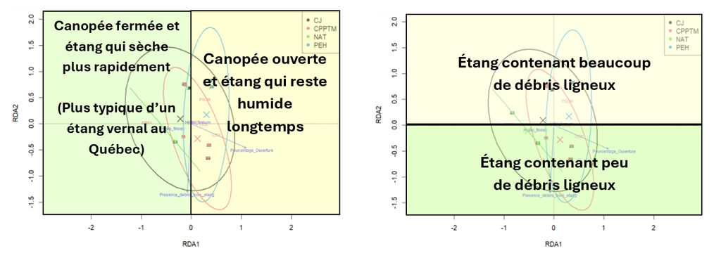

   Enfin, voici le graphique:

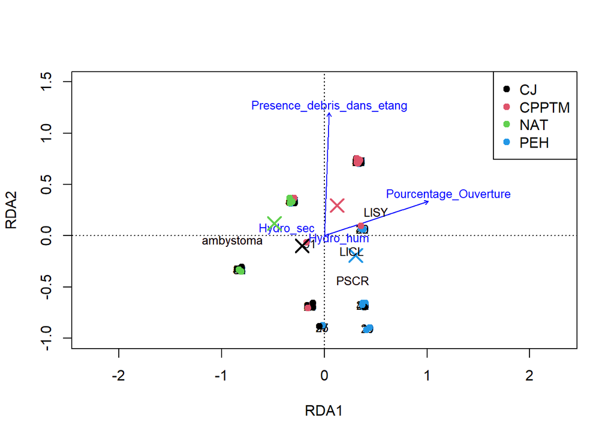

   ```r
   plot(modrda6, xlim = c(-1.5, 1.5), ylim = c(-1, 1.5), cex=0.8)
   points(scores3_jit[,1],scores3_jit[,2], display = 'sites' , col = as.numeric(trait2), pch=19)
   points(cent3$RDA1, cent3$RDA2, pch = 4, cex = 2, lwd = 2, col = 1:length(levels(trait2)))
   text(modrda6, display = "species", cex=0.8 )
   legend("topright", legend = levels(trait2), col = 1:length(levels(trait2)), pch = 19)
   ```

| n NAT = 6 n CJ = 19 | n CPPTM = 15 n PEH = 17 |
| --- | --- |

5. **Conclusion :**

   Premièrement, la création de modèle à l’aide de ordistep() a permis de révéler que les trois valeurs environnementales qui influencent le plus les communautés d’amphibiens soit: le pourcentage d’ouverture de la canopée, l’hydropériode des étangs puis la présence de débris dans l’étang. Ensemble, ces variables expliquent 28.96% de la variation des communautés. Il est toutefois important de noter que les deux variables les plus importantes semblent être l’ouverture de la canopée et l’hydropériode:

   ```r
   modrda9 <- rda(sp3~ Pourcentage_Ouverture+ Hydro_)
   RsquareAdj(modrda9)
   ```

   ```
   $r.squared
   [1] 0.2749424

   $adj.r.squared
   [1] 0.2480884
   ```

   Reste que, à elles seules, ces valeurs expliquent 24,81% de la variation des communautés.

   Avec la RDA, il semblerait que les ambystomes soit plutôt associées aux caractéristiques classiques d’un étang vernal (canopée fermée avec courte hydropériode). Ces caractéristiques sembleraient associés aux traitements NAT et CJ. Les LISY semblent beaucoup plus résistants à l’ouverture de la cannopée que les ambystomes. Ceci pourrait être expliqué par leur capacité de déplacement plus développées. Les grenouilles vertes (LICL) semblent associées avec les plantations.

   À noter que les ambystomes sont seules dans leur coin, celles-ci pourraient donc être à la source de la variation des populations entre les différents types de traitements puisque ce genre est celui qui diffère le plus des autres espèces d’amphibiens qui sont relativement proches les un des autres.

## Exploration des variables environnementales

### Ouverture de la cannopée:

1. **Préparation de la base de donnée :**

   ```r
   df <-read_excel("C:/Users/super/Université du Québec en Outaouais/CLAUDIE ÉTANGS VERNAUX - Documents/Stats/Structure_des_communautes/Data_Base_presenceV7.xlsx", sheet = 1)
   df2 <- df[, c(1, 6, 11)]
   df2$Traitement <- as.factor(df2$Traitement)
   df2$No_etang <- as.factor(df2$No_etang)
   df2
   ```

   ```
   # A tibble: 57 × 3
      No_etang   Traitement Ouverture
      <fct>      <fct>          <dbl>
    1 1WATCJ6    CJ             17.2
    2 2WATCJ5    CJ              5.2
    3 3WATCJ1    CJ             26
    4 4WATCJ2    CJ              1.04
    5 5WATCJ4    CJ              4.68
    6 6WATCJ3    CJ              8.58
    7 17WATPEH10 PEH            51.0
    8 7WATPEH2   PEH            72.8
    9 12WATPEH5  PEH            78.3
   10 8WATPEH1   PEH            44.7
   # ℹ 47 more rows
   ```

2. **Choix de l’analyse :**

   On commence en vérifiant la normalité des résidus:

   ```r
   mod <- lm(df2$Ouverture ~ df2$Traitement)
   shapiro.test(residuals(mod))
   ```

   ```
       Shapiro-Wilk normality test

   data:  residuals(mod)
   W = 0.92081, p-value = 0.001148
   ```

   Les résidus ne sont pas normaux. C’est donc mieux de faire une analyse de Kruskal–Wallis et non une ANOVA.
3. **Analyse de Kruskal–Wallis :**

   ```r
   kruskal.test(Ouverture ~ Traitement, data = df2)
   ```

   ```
       Kruskal-Wallis rank sum test

   data:  Ouverture by Traitement
   Kruskal-Wallis chi-squared = 40.747, df = 3, p-value = 7.4e-09
   ```

   C’est significatif, l’ouverture de la canopée diffère significativement dans au moins un des types de traitements.
4. **Post-hoc : DunnTest avec correction de Holm**

   ```r
   library(FSA)
   dunnTest(Ouverture ~ Traitement,data = df2, method = "holm")
   ```

   ```
      Comparison          Z      P.unadj        P.adj
   1  CJ - CPPTM -4.6545244 3.247295e-06 1.623647e-05
   2    CJ - NAT  1.4241957 1.543898e-01 3.087797e-01
   3 CPPTM - NAT  4.7088565 2.491103e-06 1.494662e-05
   4    CJ - PEH -4.1683031 3.068756e-05 9.206269e-05
   5 CPPTM - PEH  0.6099421 5.419001e-01 5.419001e-01
   6   NAT - PEH -4.3350305 1.457399e-05 5.829596e-05
   ```

   Ici, ils diffèrent tous sauf CPPTM-PEH et CJ-NAT qui se ressemblent au niveau de l’ouverture de la cannopée.
5. **Visualisation :**

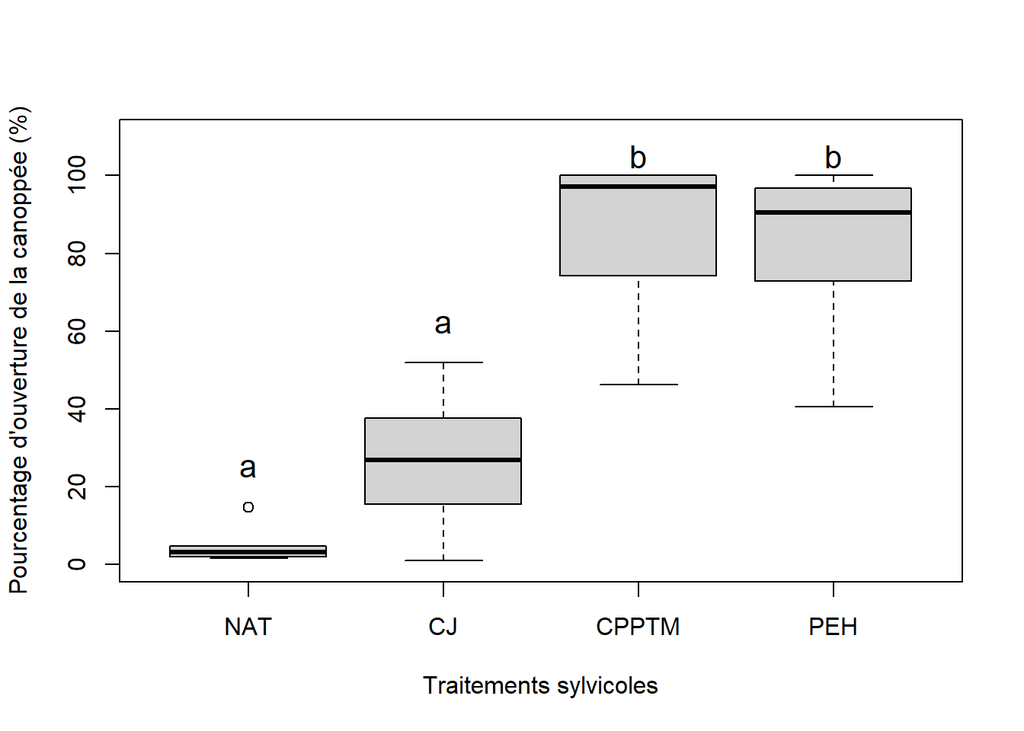

   ```r
   df2$Traitement <- factor(df2$Traitement, levels = c("NAT", "CJ", "CPPTM", "PEH"))

   boxplot(df2$Ouverture ~ df2$Traitement,ylab = "Pourcentage d'ouverture de la canoppée (%)", xlab = "Traitements sylvicoles",ylim=c(0,110))
   text(x = 1, y = 25, labels = "a", cex = 1.3)   # NAT
   text(x = 2, y = 62, labels = "a", cex = 1.3)  # CJ
   text(x = 3, y = 105, labels = "b", cex = 1.3)   # CPPTM
   text(x = 4, y = 105, labels = "b", cex = 1.3)  # PEH
   ```

| n NAT = 6 n CJ = 19 | n CPPTM = 15 n PEH = 17 |
| --- | --- |

6. **Conclusion :**

   Le pourcentage de l’ouverture de la canopée des CJ est similaire à celle dans les références en milieu naturel. L’ouverture de la canopée dans les plantations n’est pas du tout similaire à celle du milieu naturel et ressemble plutôt à celle des traitements CPPTM qui coupe presque la majorité de la canopée. Ceci pourrait expliquer pourquoi les ambystomes ne sont presque pas présentes dans les plantations.

### Hydrologie :

1. **Préparation des données :**

   ```r
   df3 <-read_excel("C:/Users/super/Université du Québec en Outaouais/CLAUDIE ÉTANGS VERNAUX - Documents/Stats/Structure_des_communautes/Data_Base_presenceV7.xlsx", sheet = 1)
   df4 <- df3[, c(1, 6, 14)]
   df4$Traitement <- as.factor(df4$Traitement)
   df4$No_etang <- as.factor(df4$No_etang)
   df4$Hydro <- factor(df4$Hydro, levels = c("sec", "hum"))
   df4
   ```

   ```
   # A tibble: 57 × 3
      No_etang   Traitement Hydro
      <fct>      <fct>      <fct>
    1 1WATCJ6    CJ         hum
    2 2WATCJ5    CJ         hum
    3 3WATCJ1    CJ         sec
    4 4WATCJ2    CJ         sec
    5 5WATCJ4    CJ         hum
    6 6WATCJ3    CJ         sec
    7 17WATPEH10 PEH        hum
    8 7WATPEH2   PEH        hum
    9 12WATPEH5  PEH        hum
   10 8WATPEH1   PEH        hum
   # ℹ 47 more rows
   ```

2. **Choix de l’analyse :**

   Cette base de donnée n’est pas idéale puisqu’elle est binaire ‘’sec’’ ou ‘’humide’’. De plus, il y a la présence de zéro puisqu’aucun étang dans PEH n’a séché:

   ```r
   table(df4$Traitement, df4$Hydro)
   ```

   ```
           sec hum
     CJ      8  11
     CPPTM   4  11
     NAT     4   2
     PEH     0  17
   ```

   Ainsi, un GLM binomial avec méthode brglmFit (puisqu’il y a des zéros) sera utilisé.
3. **GLM :**

   ```r
   library(brglm2)
   mod2 <- glm(Hydro ~ Traitement,data=df4,family=binomial,method="brglmFit")
   anova(mod2, test="Chisq")
   ```

   ```
   Analysis of Deviance Table

   Model: binomial, link: logit

   Response: Hydro

   Terms added sequentially (first to last)

              Df Deviance Resid. Df Resid. Dev Pr(>Chi)
   NULL                          56     67.676
   Traitement  3   15.787        53     51.889 0.001254 **
   ---
   Signif. codes:  0 '***' 0.001 '**' 0.01 '*' 0.05 '.' 0.1 ' ' 1
   ```

   L’anova ressort significatif. Théoriquement, l’hydrologie d’un traitement diffère des autres. Pour ‘’double check’’ on peut aussi faire un Fisher test:

   ```r
   table_hydro <- table(df4$Traitement, df4$Hydro)
   fisher.test(table_hydro)
   ```

   ```
       Fisher's Exact Test for Count Data

   data:  table_hydro
   p-value = 0.001638
   alternative hypothesis: two.sided
   ```

   Le même résultat a été obtenu, c’est significatif.
4. **DHARMa :**

   Il faut s’assurer que le modèle est correct avant de commencer l’interprétation.

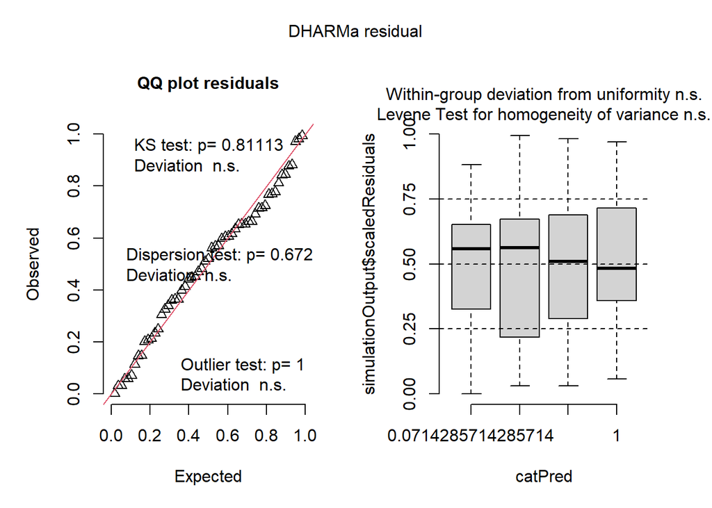

   ```r
   library(DHARMa)
   res <- simulateResiduals(mod2, n=1000)
   plot(res)
   ```

   Généralement bon.
5. **Post-hoc : Pairwise avec correction de holm** (évite les faux-positifs)

   ```r
   library(emmeans)
   pairs(emmeans(mod2, ~Traitement, type="response"), adjust="holm")
   ```

   ```
    contrast    odds.ratio     SE  df null z.ratio p.value
    CJ / CPPTM      0.5294 0.3910 Inf    1  -0.861  0.7179
    CJ / NAT        2.4353 2.3600 Inf    1   0.917  0.7179
    CJ / PEH        0.0387 0.0598 Inf    1  -2.103  0.1775
    CPPTM / NAT     4.6000 4.7300 Inf    1   1.485  0.4124
    CPPTM / PEH     0.0730 0.1160 Inf    1  -1.653  0.3937
    NAT / PEH       0.0159 0.0270 Inf    1  -2.431  0.0903

   P value adjustment: holm method for 6 tests
   Tests are performed on the log odds ratio scale
   ```

   Ici, nous avons un problème: rien n’est significatif avec la correction de holm! Toutefois, il semblerait que l’hydropériode des étangs de NAT-PEH pourraient être différents. Par contre, puisque le n PEH= 17 et n NAT= 6, il semblerait que le nombre d’échantillonage de NAT soit trop bas pour être certain.
6. **Visualisation :**

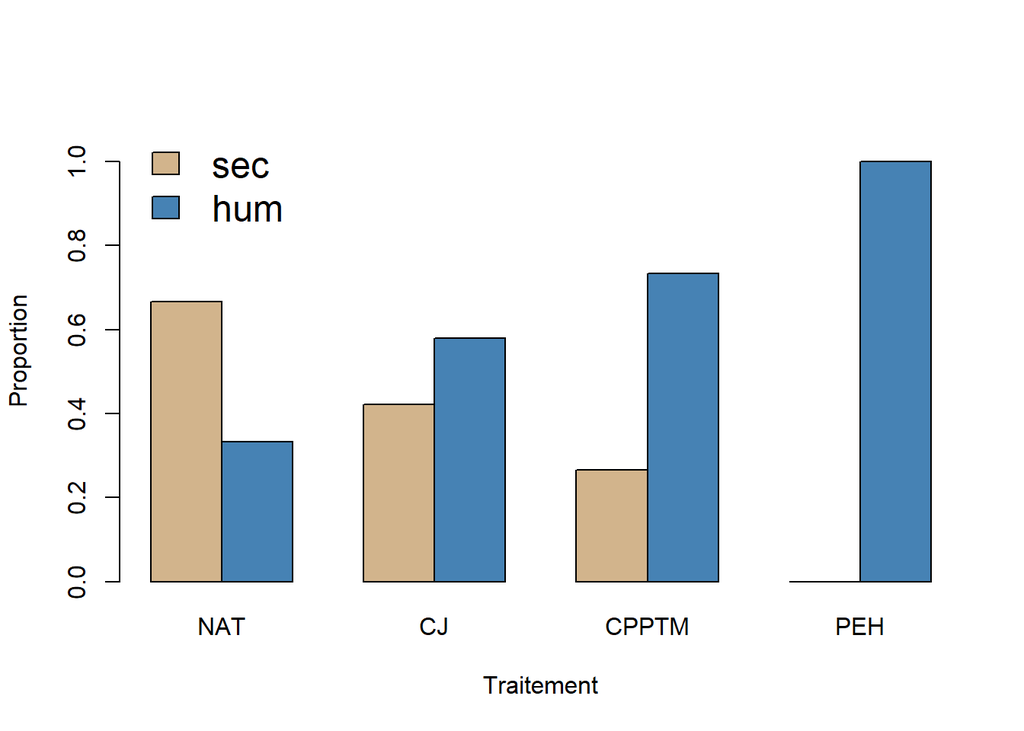

   ```r
   df4$Traitement <- factor(df4$Traitement, levels = c("NAT", "CJ", "CPPTM", "PEH"))
   tab <- prop.table(table(df4$Traitement, df4$Hydro), margin = 1)

   barplot(t(tab),
           beside = TRUE,
           col = c("tan", "steelblue"),
           ylim = c(0,1.1),
           ylab = "Proportion",
           xlab = "Traitement")

   legend("topleft",
          legend = c("sec","hum"),
          fill = c("tan","steelblue"),
          bty = "n",
          cex=1.5)
   ```

| n NAT = 6 n CJ = 19 | n CPPTM = 15 n PEH = 17 |
| --- | --- |

7. **Conclusion** :

   Ici, il n’y a pas assez de données pour obtenir un résultat significatif. Toutefois, en regardant le graphique à barre, une tendance semble claire: Les étangs dans les plantations ne semble presque jamais sécher alors que ceux dans les NAT et CJ semble sécher beaucoup plus souvent. Ainsi, l’hydrologie des étangs dans les plantations ne semblent pas refléter ce qui est observé en nature.

### Débris ligneux dans l’étang :

1. **Préparation des données :**

   ```r
   df5 <-read_excel("C:/Users/super/Université du Québec en Outaouais/CLAUDIE ÉTANGS VERNAUX - Documents/Stats/Structure_des_communautes/Data_Base_presenceV7.xlsx", sheet = 1)
   df6 <- df5[, c(1, 6, 12)]
   df6$Traitement <- as.factor(df6$Traitement)
   df6$No_etang <- as.factor(df6$No_etang)
   df6$Debris_in<- factor(df6$Debris_in,levels = c("abscence","faible","moyen","eleve"),ordered = TRUE)
   df6
   ```

   ```
   # A tibble: 57 × 3
      No_etang   Traitement Debris_in
      <fct>      <fct>      <ord>
    1 1WATCJ6    CJ         faible
    2 2WATCJ5    CJ         abscence
    3 3WATCJ1    CJ         abscence
    4 4WATCJ2    CJ         faible
    5 5WATCJ4    CJ         abscence
    6 6WATCJ3    CJ         abscence
    7 17WATPEH10 PEH        abscence
    8 7WATPEH2   PEH        abscence
    9 12WATPEH5  PEH        abscence
   10 8WATPEH1   PEH        abscence
   # ℹ 47 more rows
   ```

2. **Choix des analyses :**

   On recherche un test qui est capable de prendre en compte les niveaux de débris:  
   absence < faible < moyen < élevé  
   Une régression logistique ordianle (CLM) serait alors idéale. Par contre, il y a beaucoup de zéros dans la base de donnée:

   ```r
   table(df6$Traitement,df6$Debris_in)
   ```

   ```
           abscence faible moyen eleve
     CJ          16      3     0     0
     CPPTM        4      4     5     2
     NAT          0      5     1     0
     PEH         13      3     1     0
   ```

   Il faut donc s’assurer que le modèle converge avant de continuer :

   ```r
   library(ordinal)
   mod3 <- clm(Debris_in ~ Traitement, data = df6)
   summary(mod3)
   ```

   ```
   formula: Debris_in ~ Traitement
   data:    df6

    link  threshold nobs logLik AIC    niter max.grad cond.H
    logit flexible  57   -47.00 106.01 5(0)  8.69e-09 3.9e+01

   Coefficients:
                   Estimate Std. Error z value Pr(>|z|)
   TraitementCPPTM   3.3205     0.8765   3.788 0.000152 ***
   TraitementNAT     3.0039     0.9604   3.128 0.001761 **
   TraitementPEH     0.5466     0.8472   0.645 0.518786
   ---
   Signif. codes:  0 '***' 0.001 '**' 0.01 '*' 0.05 '.' 0.1 ' ' 1

   Threshold coefficients:
                   Estimate Std. Error z value
   abscence|faible   1.7030     0.6267   2.717
   faible|moyen      3.6976     0.7841   4.716
   moyen|eleve       5.5781     1.0280   5.426
   ```

   Ici, le modèle converge de manière excellente (max.grad = 8.69 x 10^-9 ce qui est nottament meilleur que le seuil recommandé de moins de 10^-6).

   Niter 5 signifie que ça a pris que 5 itérations pour que le modèle converge ce qui est bien.  
   Les colones de Std. Error sont basses ce qui indique le bon fonctionnement du modèle.  
   Les Threshold coefficients sont bien ordonnées.

   Tout indique que le modèle est acceptable, donc ce sera un CLM qui sera effectué.
3. **CLM :**

   ```r
   anova(mod3)
   ```

   ```
   Type I Analysis of Deviance Table with Wald chi-square tests

              Df  Chisq Pr(>Chisq)
   Traitement  3 19.616  0.0002039 ***
   ---
   Signif. codes:  0 '***' 0.001 '**' 0.01 '*' 0.05 '.' 0.1 ' ' 1
   ```

   Le p-value est significatif, les niveaux de présence de débris diffère dans au moins un type de traitement sylvicole.
4. **Post-Hoc : Emmeans**

   ```r
   emm2 <-  emmeans(mod3, ~ Traitement)
   pairs(emm2, adjust = "holm")
   ```

   ```
    contrast    estimate    SE  df z.ratio p.value
    CJ - CPPTM    -3.321 0.877 Inf  -3.788  0.0009
    CJ - NAT      -3.004 0.960 Inf  -3.128  0.0070
    CJ - PEH      -0.547 0.847 Inf  -0.645  1.0000
    CPPTM - NAT    0.317 0.845 Inf   0.375  1.0000
    CPPTM - PEH    2.774 0.832 Inf   3.333  0.0043
    NAT - PEH      2.457 0.921 Inf   2.669  0.0228

   P value adjustment: holm method for 6 tests
   ```

   Les traitements diffèrent tous sauf les paires CJ-PEH et CPPTM-NAT.
5. **Visualisation :**

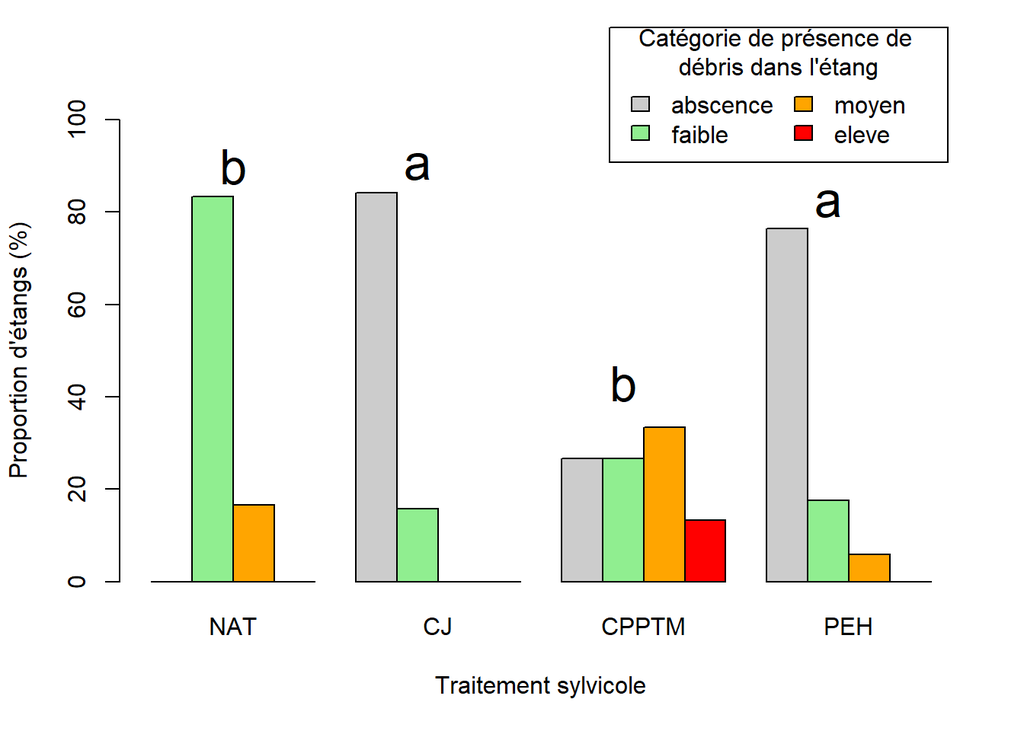

   ```r
   df6$Traitement <- factor(df6$Traitement, levels = c("NAT", "CJ", "CPPTM", "PEH"))
   tab1 <- table(df6$Traitement, df6$Debris_in)
   prop <- prop.table(tab1, margin = 1)* 100 #c'est plus intéressant si je montre les proportions
   cols <- c("grey80", "lightgreen", "orange", "red")

   barplot(t(prop), beside = TRUE, xlab = "Traitement sylvicole", ylab = "Proportion d'étangs (%)",ylim = c(0,100), names.arg = rownames(tab1), legend.text = colnames(tab1), col = cols, args.legend = list(title = "Catégorie de présence de \ndébris dans l'étang", y = 120,ncol=2))
   text(x = 3, y = 90, labels = "b", cex = 2)   # NAT
   text(x = 7.5, y = 90, labels = "a", cex = 2)  # CJ
   text(x = 12.5, y = 43, labels = "b", cex = 2)   # CPPTM
   text(x = 17.5, y = 82, labels = "a", cex = 2)  # PEH
   ```

| n NAT = 6 n CJ = 19 | n CPPTM = 15 n PEH = 17 |
| --- | --- |

6. **Conclusion :**

   Ici, le niveau de présence de débris ligneux dans le traitement NAT serait significativement différent de CJ et PEH, tous deux ayant majoritairement un abscence de débris ligneux. Encore une fois, les plantations diffèrent du milieu naturel.

## Est-ce certaines espèces sont associés à certains traitements sylvicoles ? Pourquoi ?

Les types de traitements modifie l’habitat des amphibiens, notamment, l’ouverture de la canopée, la présence de débris dans les étant et, probablement (mais sans résultats définitifs), l’hydropériode. La RDA précédente semble avoir révélé que les ambystomes sont des espèces spécifiquement associées à un habitat différent que les autres amphibiens puisqu’elles sont isolée dans un coin près de NAT et CJ. Serait-elles des espèces indicatrices qui expliquerait la séparation significative de la communautée entre NAT/CJ et les autres types de traitements?

1.1 **Préparation des données:**

```r
df <-read_excel("C:/Users/super/Université du Québec en Outaouais/CLAUDIE ÉTANGS VERNAUX - Documents/Stats/Structure_des_communautes/Data_Base_presenceV7.xlsx", sheet = 1)
sp <- df[, c("ambystoma", "LISY", "LICL", "PSCR")]
sp
```

```
# A tibble: 57 × 4
   ambystoma  LISY  LICL  PSCR
       <dbl> <dbl> <dbl> <dbl>
 1         0     1     0     0
 2         1     1     0     0
 3         1     0     0     0
 4         1     0     0     0
 5         1     1     0     0
 6         1     1     0     1
 7         0     1     0     0
 8         0     1     0     1
 9         0     1     0     1
10         0     1     0     1
# ℹ 47 more rows
```

1.2 **Choix de l’analyse :**

Le code suivant révèle qu’aucune espèce est excessivement rare:

```r
colSums(sp)
```

```
ambystoma      LISY      LICL      PSCR
       28        50        10        18
```

Ainsi, il est possible de faire l’analyse IndVal (Indicator Species Analysis) pour répondre à la question.

1.3 **IndVal :**

```r
library(indicspecies)
res <- multipatt(sp,cluster = df$Traitement,func = "IndVal.g",control = how(nperm = 9999))
summary(res)
```

```
 Multilevel pattern analysis
 ---------------------------

 Association function: IndVal.g
 Significance level (alpha): 0.05

 Total number of species: 4
 Selected number of species: 1
 Number of species associated to 1 group: 0
 Number of species associated to 2 groups: 1
 Number of species associated to 3 groups: 0

 List of species associated to each combination:

 Group CJ+NAT  #sps.  1
           stat p.value
ambystoma 0.785   2e-04 ***
---
Signif. codes:  0 '***' 0.001 '**' 0.01 '*' 0.05 '.' 0.1 ' ' 1
```

**2.1 Pousser plus loin : Qu’est-ce qui explique la présence des ambystomes dans les NAT/CJ ?**

On sait que les traitements affecte l’habitat et on a découvert que les valeurs environnementales suivantes semblent celles qui détermine le plus les communautés d’amphibiens: L’ouverture de la canopée, l’hydropériode et la présence de débris dans les étangs. Mais, spécifiquement pour les ambystomes, qui ont maintenant été définie comme des espèces indicatrices de CJ/NAT, quel valeur environnementales influence le plus leur présence/absence dans l’habitat?

2.2 **Préparation des données :**

```r
df <-read_excel("C:/Users/super/Université du Québec en Outaouais/CLAUDIE ÉTANGS VERNAUX - Documents/Stats/Structure_des_communautes/Data_Base_presenceV7.xlsx", sheet = 1)
df$Traitement <- as.factor(df$Traitement)
df$Ouverture <- as.numeric(df$Ouverture)
df[, 2:5] <- lapply(df[, 2:5], as.numeric)
df$Debris_in<- as.numeric(factor(df$Debris_in,levels = c("abscence", "faible", "moyen", "eleve"),ordered = TRUE))
#pour débris, voici les codes: 1=abscence, 2=faible, 3=moyen, 4=eleve)
df$Hydro<- factor(df$Hydro, levels = c("hum", "sec"))
df
```

```
# A tibble: 57 × 14
   No_etang   ambystoma  LICL  LISY  PSCR Traitement Ph_moy Temp_moy superficie
   <chr>          <dbl> <dbl> <dbl> <dbl> <fct>       <dbl>    <dbl>      <dbl>
 1 1WATCJ6            0     0     1     0 CJ           6.64     15.0    165000
 2 2WATCJ5            1     0     1     0 CJ           6.58     16.6    434700
 3 3WATCJ1            1     0     0     0 CJ           6.44     12.0     26600
 4 4WATCJ2            1     0     0     0 CJ           6.62     17.7    380800
 5 5WATCJ4            1     0     1     0 CJ           6.38     18.6     72000
 6 6WATCJ3            1     0     1     1 CJ           6.26     18.5    240000
 7 17WATPEH10         0     0     1     0 PEH          6.49     22.2     62059.
 8 7WATPEH2           0     0     1     1 PEH          6.33     15.6    267285.
 9 12WATPEH5          0     0     1     1 PEH          6.32     17.5    574453.
10 8WATPEH1           0     0     1     1 PEH          6.49     13.9    133706.
# ℹ 47 more rows
# ℹ 5 more variables: volume <dbl>, Ouverture <dbl>, Debris_in <dbl>,
#   Debris_out <chr>, Hydro <fct>
```

```r
Traitement <- df$Traitement
Ouverture <- df$Ouverture
df$Debris_in <- ordered(df$Debris_in)
Debris_in <- df$Debris_in
Hydro <- df$Hydro
```

2.3 **Choix de l’analyse** :  
Pour pouvoir analyser l’impact de chaque valeur environnementales, il serait préférable de comparer des modèles de GLM entre eux. Pour se faire, je vais juste m’assurer qu’un modèle global respecte les conditions d’un GLM:

```r
mod_test <- glm(ambystoma ~ Traitement + Ouverture + Hydro + Debris_in ,family = binomial, data=df)
table(df$Traitement, df$ambystoma)
```

```
         0  1
  CJ     5 14
  CPPTM  9  6
  NAT    0  6
  PEH   15  2
```

```r
summary(mod_test)
```

```
Call:
glm(formula = ambystoma ~ Traitement + Ouverture + Hydro + Debris_in,
    family = binomial, data = df)

Coefficients:
                  Estimate Std. Error z value Pr(>|z|)
(Intercept)       -3.60304 1153.05107  -0.003   0.9975
TraitementCPPTM   -0.34450    1.41818  -0.243   0.8081
TraitementNAT     18.35896 2557.24001   0.007   0.9943
TraitementPEH     -2.43395    1.40075  -1.738   0.0823 .
Ouverture         -0.01159    0.02069  -0.560   0.5754
Hydrosec           0.49274    0.90341   0.545   0.5855
Debris_in.L      -12.06905 3093.95927  -0.004   0.9969
Debris_in.Q       -8.37852 2306.10110  -0.004   0.9971
Debris_in.C       -5.25075 1031.32013  -0.005   0.9959
---
Signif. codes:  0 '***' 0.001 '**' 0.01 '*' 0.05 '.' 0.1 ' ' 1

(Dispersion parameter for binomial family taken to be 1)

    Null deviance: 79.001  on 56  degrees of freedom
Residual deviance: 47.277  on 48  degrees of freedom
AIC: 65.277

Number of Fisher Scoring iterations: 17
```

Ici, on a clairement un problème ! Il y a une séparation complète pour le traitement NAT. Tout les traitements NAT ont des ambystomes alors le modèle nous donne un Standard Error hyper élevé.  
Il est nécessaire de corriger ce problème avec une régression pénalisée

```r
library(brglm2)
library(car)
library(DHARMa)
mod_test <- glm(ambystoma ~ Traitement + Ouverture + Hydro + Debris_in ,family = binomial,  method = "brglmFit", data=df)
summary(mod_test)
```

```
Call:
glm(formula = ambystoma ~ Traitement + Ouverture + Hydro + Debris_in,
    family = binomial, data = df, method = "brglmFit")

Deviance Residuals:
    Min       1Q   Median       3Q      Max
-1.8359  -0.6555  -0.2829   0.7635   1.9805

Coefficients:
                 Estimate Std. Error z value Pr(>|z|)
(Intercept)      0.531467   1.188802   0.447    0.655
TraitementCPPTM -0.373860   1.350277  -0.277    0.782
TraitementNAT    2.304848   1.875801   1.229    0.219
TraitementPEH   -2.143548   1.332746  -1.608    0.108
Ouverture       -0.009332   0.019529  -0.478    0.633
Hydrosec         0.362623   0.836272   0.434    0.665
Debris_in.L     -0.752701   1.502388  -0.501    0.616
Debris_in.Q     -0.082734   1.157287  -0.071    0.943
Debris_in.C     -1.286107   0.964078  -1.334    0.182

(Dispersion parameter for binomial family taken to be 1)

    Null deviance: 79.001  on 56  degrees of freedom
Residual deviance: 49.312  on 48  degrees of freedom
AIC:  67.312

Type of estimator: AS_mixed (mixed bias-reducing adjusted score equations)
Number of Fisher Scoring iterations: 21
```

```r
vif(mod_test) #pas de collinéarité, c'est ok
```

```
               GVIF Df GVIF^(1/(2*Df))
Traitement 6.211868  3        1.355825
Ouverture  3.959910  1        1.989952
Hydro      1.292277  1        1.136784
Debris_in  2.394475  3        1.156649
```

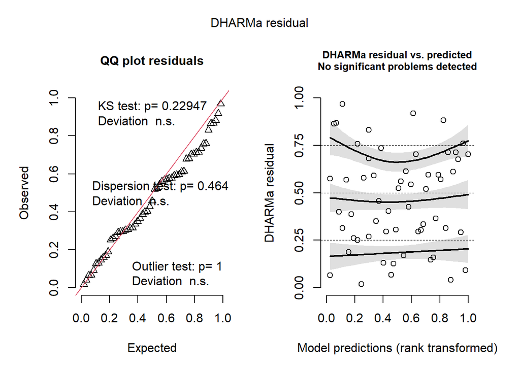

```r
res <- simulateResiduals(mod_test) #validation du modèle corrigé
plot(res)
```

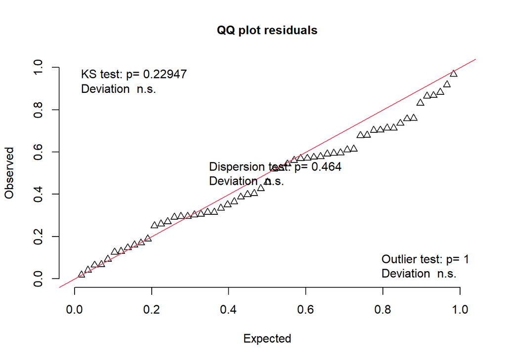

```
    Exact one-sample Kolmogorov-Smirnov test

data:  simulationOutput$scaledResiduals
D = 0.13486, p-value = 0.2295
alternative hypothesis: two-sided
```

```r
testUniformity(res) #uniformité des résidus (p-value plus de 0.05) Good!
```

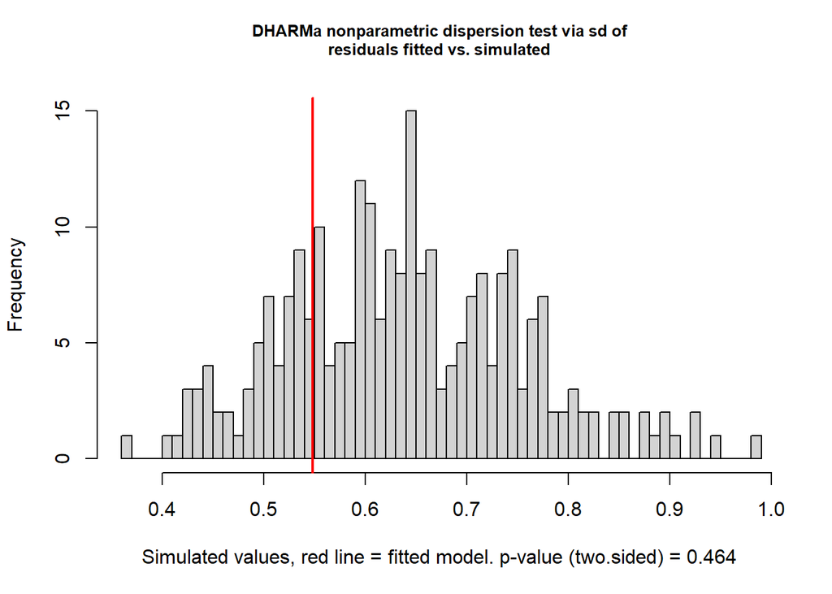

```
    DHARMa nonparametric dispersion test via sd of residuals fitted vs.
    simulated

data:  simulationOutput
dispersion = 0.8574, p-value = 0.464
alternative hypothesis: two.sided
```

```r
testDispersion(res) #Pas de surdispersion (p-value plus de 0.05) Good!
```

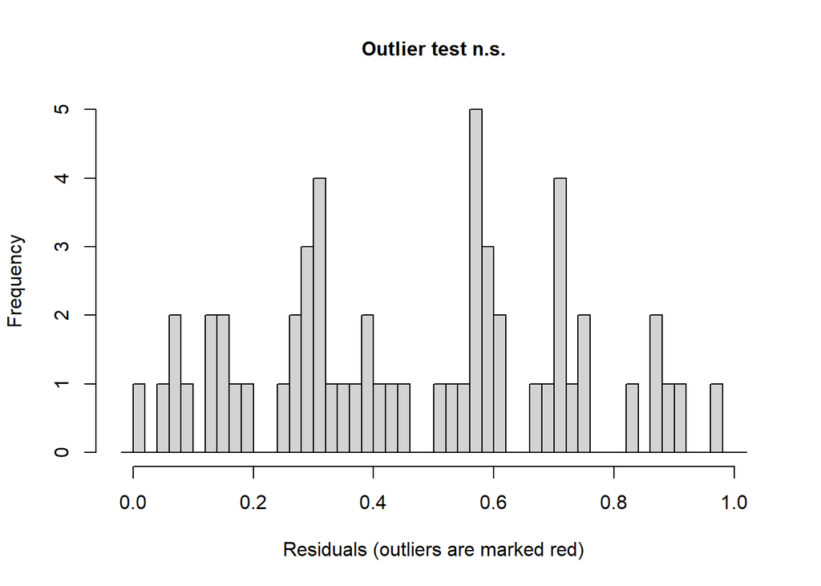

```
    DHARMa bootstrapped outlier test

data:  res
outliers at both margin(s) = 0, observations = 57, p-value = 1
alternative hypothesis: two.sided
 percent confidence interval:
 0 0
sample estimates:
outlier frequency (expected: 0 )
                               0
```

```r
testOutliers(res) #0 Outliers, Good!
```

La régression pénalisé a bien ajusté le modèle. Par contre, pour que les modèles soient tous comparables, ceux-ci doivent tous avoir cette pénalité.

2.4 **Comparaison des GLM avec Régression Pénalisées :**

-Débris dans les étangs

```r
mod_debris <- glm(ambystoma ~ Debris_in,family = binomial,method = "brglmFit",data = df)
```

Pour savoir si la correction de cette problématique est pertinant, j’ai essayé de voir si cette valeur était vraiment importante ou non pour expliquer la présence des ambystomes.

```r
#Note: On ne peux pas utiliser la fonction aictab à cause de brglmFit! On doit donc la faire de manière manuelle
AICc <- function(model) {
  n <- nobs(model)
  k <- length(coef(model))
  AIC(model) + (2*k*(k+1))/(n-k-1)
}

#modèle sans l'inclusion de débris
mod_sans_debris <- glm(ambystoma ~ Traitement + Ouverture + Hydro,family = binomial,method = "brglmFit",data=df)

#modèle global qui inclus les débris
mod_global <- glm(ambystoma ~ Traitement + Ouverture + Hydro + Debris_in,family = binomial,method = "brglmFit",data = df)

#Création d'un tableau pour voir si l'inclusion des débris est vraiment important
Test_debris <- list(
  Sans = mod_sans_debris,
  Avec = mod_global)
aicc_debris <- sapply(Test_debris, AICc)
resultats_debris <- data.frame(
  Modele = names(aicc_debris),
  AICc = aicc_debris)
resultats_debris$Delta_AICc <- resultats_debris$AICc - min(resultats_debris$AICc)
resultats_debris$Poids <- exp(-0.5 * resultats_debris$Delta_AICc) /
  sum(exp(-0.5 * resultats_debris$Delta_AICc))
resultats_debris[order(resultats_debris$AICc), ]
```

```
     Modele     AICc Delta_AICc     Poids
Sans   Sans 66.76851   0.000000 0.8990283
Avec   Avec 71.14146   4.372948 0.1009717
```

C’est très clair, les débris dans les étangs ne semblent pas contribuer de manière importante à la présence/absence des ambystomes. Il est donc préférable de les retirer des modèles. Surtout s’il pose problème.

-Ouverture de la canopée

```r
mod_can <- glm(ambystoma ~ Ouverture,family = binomial,method = "brglmFit",data = df)
summary(mod_can)
```

```
Call:
glm(formula = ambystoma ~ Ouverture, family = binomial, data = df,
    method = "brglmFit")

Deviance Residuals:
    Min       1Q   Median       3Q      Max
-1.7979  -0.7564  -0.6244   0.8143   1.8606

Coefficients:
             Estimate Std. Error z value Pr(>|z|)
(Intercept)  1.873411   0.616932   3.037  0.00239 **
Ouverture   -0.034094   0.009496  -3.590  0.00033 ***
---
Signif. codes:  0 '***' 0.001 '**' 0.01 '*' 0.05 '.' 0.1 ' ' 1

(Dispersion parameter for binomial family taken to be 1)

    Null deviance: 79.001  on 56  degrees of freedom
Residual deviance: 61.096  on 55  degrees of freedom
AIC:  65.096

Type of estimator: AS_mixed (mixed bias-reducing adjusted score equations)
Number of Fisher Scoring iterations: 3
```

```r
#vérification de la validité du modèle
res2 <- simulateResiduals(mod_can)
testUniformity(res2) #uniformité des résidus (p-value plus de 0.05) Good!
```

```
    Exact one-sample Kolmogorov-Smirnov test

data:  simulationOutput$scaledResiduals
D = 0.11631, p-value = 0.3935
alternative hypothesis: two-sided
```

```r
testDispersion(res2) #Pas de surdispersion (p-value plus de 0.05) Good!
```

```
    DHARMa nonparametric dispersion test via sd of residuals fitted vs.
    simulated

data:  simulationOutput
dispersion = 0.99339, p-value = 0.96
alternative hypothesis: two.sided
```

```r
testOutliers(res2) #Zéro Outliers, good!
```

```
    DHARMa bootstrapped outlier test

data:  res2
outliers at both margin(s) = 0, observations = 57, p-value = 1
alternative hypothesis: two.sided
 percent confidence interval:
 0 0
sample estimates:
outlier frequency (expected: 0 )
                               0
```

Le summary indique que la canopée influence significativement la présence/absence des ambystomes. L’Estimate négatif indique que plus la canopée est fermée, plus il y a de chances que l’ambystome soit présente.

-Hydropériode

```r
mod_hydro <- glm(ambystoma ~ Hydro,family = binomial,method = "brglmFit",data = df)
summary(mod_hydro)
```

```
Call:
glm(formula = ambystoma ~ Hydro, family = binomial, data = df,
    method = "brglmFit")

Deviance Residuals:
    Min       1Q   Median       3Q      Max
-1.7779  -0.9597  -0.9597   1.4120   1.4120

Coefficients:
            Estimate Std. Error z value Pr(>|z|)
(Intercept)  -0.5363     0.3236  -1.657  0.09750 .
Hydrosec      1.8862     0.6979   2.703  0.00687 **
---
Signif. codes:  0 '***' 0.001 '**' 0.01 '*' 0.05 '.' 0.1 ' ' 1

(Dispersion parameter for binomial family taken to be 1)

    Null deviance: 79.001  on 56  degrees of freedom
Residual deviance: 69.328  on 55  degrees of freedom
AIC:  73.328

Type of estimator: AS_mixed (mixed bias-reducing adjusted score equations)
Number of Fisher Scoring iterations: 4
```

```r
#Vérification de la validité du modèle
res3 <- simulateResiduals(mod_hydro)
testUniformity(res3) #uniformité des résidus (p-value plus de 0.05) Good!
```

```
    Exact one-sample Kolmogorov-Smirnov test

data:  simulationOutput$scaledResiduals
D = 0.10414, p-value = 0.5324
alternative hypothesis: two-sided
```

```r
testDispersion(res3) #Pas de surdispersion (p-value plus de 0.05) Good!
```

```
    DHARMa nonparametric dispersion test via sd of residuals fitted vs.
    simulated

data:  simulationOutput
dispersion = 1.0003, p-value = 0.992
alternative hypothesis: two.sided
```

```r
testOutliers(res3) #Zéro Outliers, good!
```

```
    DHARMa bootstrapped outlier test

data:  res3
outliers at both margin(s) = 0, observations = 57, p-value = 1
alternative hypothesis: two.sided
 percent confidence interval:
 0 0
sample estimates:
outlier frequency (expected: 0 )
                               0
```

Un autre significatif, l’hydropériode semble affecter la présence/abscence des ambystomes. Avec l’Estimate positif pour ‘’Hrydrosec’’ il semblerait que la présence des ambystomes seraient plus élevé s’il y a des étangs qui sèche par la fin l’été. Le contraire s’applique pour les étangs qui reste humides pour plus longtemps.

-La combinaison de l’ouverture de la canopée et de l’hydropériode

```r
#Modèle avec juste les composantes de l'habitat (et débris retiré)
mod_habitat2 <- glm(ambystoma ~ Ouverture + Hydro ,family = binomial,method = "brglmFit",data = df)
```

```r
#Vérification de la validité du modèle
vif(mod_habitat2) #Pas de collinéarité, Good!
```

```
Ouverture     Hydro
 1.009991  1.009991
```

```r
res5 <- simulateResiduals(mod_habitat2)
testUniformity(res5) #uniformité des résidus (p-value plus de 0.05) Good!
```

```
    Exact one-sample Kolmogorov-Smirnov test

data:  simulationOutput$scaledResiduals
D = 0.14401, p-value = 0.1704
alternative hypothesis: two-sided
```

```r
testDispersion(res5) #Pas de surdispersion (p-value plus de 0.05) Good!
```

```
    DHARMa nonparametric dispersion test via sd of residuals fitted vs.
    simulated

data:  simulationOutput
dispersion = 0.9801, p-value = 0.912
alternative hypothesis: two.sided
```

```r
testOutliers(res5) #Zéro Outliers, good!
```

```
    DHARMa bootstrapped outlier test

data:  res5
outliers at both margin(s) = 0, observations = 57, p-value = 1
alternative hypothesis: two.sided
 percent confidence interval:
 0 0
sample estimates:
outlier frequency (expected: 0 )
                               0
```

```r
#comparaison entre des modèles
anova(mod_can, mod_habitat2, test="Chisq")
```

```
Analysis of Deviance Table

Model 1: ambystoma ~ Ouverture
Model 2: ambystoma ~ Ouverture + Hydro
  Resid. Df Resid. Dev Df Deviance Pr(>Chi)
1        55     61.096
2        54     57.156  1   3.9405  0.04714 *
---
Signif. codes:  0 '***' 0.001 '**' 0.01 '*' 0.05 '.' 0.1 ' ' 1
```

```r
anova(mod_hydro, mod_habitat2, test="Chisq")
```

```
Analysis of Deviance Table

Model 1: ambystoma ~ Hydro
Model 2: ambystoma ~ Ouverture + Hydro
  Resid. Df Resid. Dev Df Deviance  Pr(>Chi)
1        55     69.328
2        54     57.156  1   12.173 0.0004849 ***
---
Signif. codes:  0 '***' 0.001 '**' 0.01 '*' 0.05 '.' 0.1 ' ' 1
```

Les deux comparaisons avec une ANOVA son significatives. Ceci confirme que l’hydropériode seule ou la canopée seule n’expliquent pas complètement la présence/absence des ambystomes. Ces deux éléments doivent être inclus pour comprendre leur répartition.

-L’effet des traitements:

```r
#Création d'un nouveau modèle global qui exclus les débris
mod_global2 <- glm(ambystoma ~ Traitement + Ouverture + Hydro,family = binomial,method = "brglmFit",data = df)
summary(mod_global2)
```

```
Call:
glm(formula = ambystoma ~ Traitement + Ouverture + Hydro, family = binomial,
    data = df, method = "brglmFit")

Deviance Residuals:
    Min       1Q   Median       3Q      Max
-1.8829  -0.7457  -0.4683   0.7933   2.1283

Coefficients:
                Estimate Std. Error z value Pr(>|z|)
(Intercept)      1.08394    0.77240   1.403    0.161
TraitementCPPTM -0.23096    1.28776  -0.179    0.858
TraitementNAT    1.04816    1.70890   0.613    0.540
TraitementPEH   -1.52731    1.26067  -1.212    0.226
Ouverture       -0.01712    0.01826  -0.937    0.349
Hydrosec         0.80524    0.78445   1.026    0.305

(Dispersion parameter for binomial family taken to be 1)

    Null deviance: 79.001  on 56  degrees of freedom
Residual deviance: 53.089  on 51  degrees of freedom
AIC:  65.089

Type of estimator: AS_mixed (mixed bias-reducing adjusted score equations)
Number of Fisher Scoring iterations: 8
```

```r
#Vérification de la validité du modèle
vif(mod_global2) #Pas de collinéarité, Good!
```

```
               GVIF Df GVIF^(1/(2*Df))
Traitement 3.870894  3        1.253050
Ouverture  3.548016  1        1.883618
Hydro      1.118824  1        1.057745
```

```r
res7 <- simulateResiduals(mod_global2)
testUniformity(res7) #uniformité des résidus (p-value plus de 0.05) Good!
```

```
    Exact one-sample Kolmogorov-Smirnov test

data:  simulationOutput$scaledResiduals
D = 0.17013, p-value = 0.06528
alternative hypothesis: two-sided
```

```r
testDispersion(res7) #Pas de surdispersion (p-value plus de 0.05) Good!
```

```
    DHARMa nonparametric dispersion test via sd of residuals fitted vs.
    simulated

data:  simulationOutput
dispersion = 0.90756, p-value = 0.616
alternative hypothesis: two.sided
```

```r
testOutliers(res7) #Zéro Outliers, good!
```

```
    DHARMa bootstrapped outlier test

data:  res7
outliers at both margin(s) = 0, observations = 57, p-value = 1
alternative hypothesis: two.sided
 percent confidence interval:
 0 0
sample estimates:
outlier frequency (expected: 0 )
                               0
```

```r
#Comparaison des modèles
anova(mod_habitat2, mod_global2, test = "Chisq")
```

```
Analysis of Deviance Table

Model 1: ambystoma ~ Ouverture + Hydro
Model 2: ambystoma ~ Traitement + Ouverture + Hydro
  Resid. Df Resid. Dev Df Deviance Pr(>Chi)
1        54     57.156
2        51     53.089  3   4.0672   0.2543
```

La comparaison est non significative. Une fois l’habitat pris en compte, les traitements n’ajoutent rien de significatif au modèle. Les différences entre les traitements semblent être largement expliquées par les différences d’ouverture de la canopée et d’hydropériode qu’ils engendrent.

2.5 **Visualisation :**

Voici les mécanismes qui influence significativement la présence/absence des ambystomes dans l’habitat créé par les différents types de traitements sylvicoles.

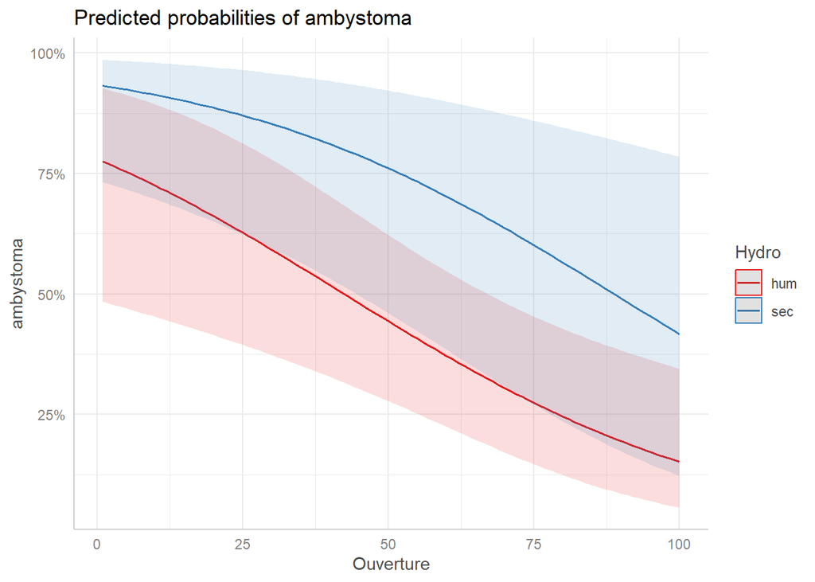

```r
library(ggeffects)
plot(ggpredict(mod_habitat2, terms = c("Ouverture", "Hydro")))
```

3.1 **Conclusion :**

Parmis toutes les espèces étudié dans ce projet, seul les ambystomes sont des espèces indicatrices d’un habitat précis. Celles-ci sont liées aux traitement NAT et CJ car ce type de traitement sylvicole mène à la création d’un habitat similaire: une canopée fermée et des étangs à hydropériode plus courte ce qui explique probablement la présence des ambystomes.

## Conclusion de l’analyse des communautées d’amphibiens:

Surprenament, la grenouille des bois, aussi dépendante des étangs vernaux, ne semble pas aussi sensible que les salamandres aux changements dans la canopée/hydropériode. Ceci pourrait être expliqué par leur capacité de déplacement plus développée. Toutefois, ceci pourrait aussi être lié à un biais d’échantillonage:  
J’ai choisi mes étangs lors de la ponte du printemps. Seulement les oeufs de LISY et d’ambystomes étaient visibles. Puisque les ambystomes ne semblent pas utiliser les plantations de PEH et les CPPTM, les étangs que choisis dans ces types de traitements contenaient obligatoirement des LISY. Puisqu’il y a beaucoup d’autres espèces dans ces habitats comme la LICL et la PSCR, si j’aurais pu voir leurs oeufs, j’aurais pu avoir la possibilité de choisir des étangs qui ne contenaient pas exclusivement que des LISY. Avec le biais de sélection présent, ça donne l’impression qu’il y a plein de LISY dans les PEH/CPPTM alors qu’ils pourraient être en fait moins commun que d’autres espèces plus cryptiques comme les LICL et PSCR. Surtout que la littérature associe les LISY avec des canopées plus fermées comparés aux autres espèces inventoriées (LICL et PSCR).

Un autre point à apporter c’est que les communautés dans les PEH et NAT ne sont pas similaires (manque de salamandres). Selon les analyses jusqu’à maintenant, les plantations ne semblent pas être un environnement adaptée pour les ambystomes et n’est pas du tout similaire au milieu naturel. Il a toutefois le potentiel de supporter des espèces avec une meilleure mobilités comme les anoures.